# WHO MMR Working Notebook

#Read-in Data

```r
library(tidyr)
library(tidyverse)
library(readxl)
library(devtools)
library(usethis)

Rfiles <- list.files(file.path(paste0(getwd(),"/R/")), ".R")
Rfiles <- Rfiles[grepl(".R", Rfiles)]
sapply(paste0(paste0(getwd(),"/R/"), Rfiles), source)
```

[output not shown]

```r
country_info <- read_excel("country list_ 26 March 2019.xlsx")
mmr_est_unrounded <- read.csv("mmr_unrounded.csv")
live_birth_projections <- read_excel("wpp2019_Births-TFR-GFR-Female1549.xlsx")
regional_groupings <- read.csv("regional_groupings_20190910_la_ac.csv")
```

#Data Cleaning

```r
country_info <- country_info %>%
  select(`Code`, `ISO_Numeric_Code_CODE`, `Title`) %>%
  rename(ISOCode = `Code`, ISONum = `ISO_Numeric_Code_CODE`)

mmr_est_unrounded <- mmr_est_unrounded %>%
  filter(`bound` == "point", `year` >= 2010) %>%
  select(-c(`q`, `perc`, `bound`)) %>%
  mutate("MMR" = `value` * 100000)

mmr_est_unrounded_pwider <- mmr_est_unrounded %>%
  select(-c(`value`)) %>%
  pivot_wider(names_from = `year`, values_from = `MMR`)

regional_groupings <- regional_groupings %>%
  select(`ISOCode`, `Country.x`, `sdg_1`)

live_birth_projections2030 <- live_birth_projections %>%
  filter(Year == 2030) %>%
  select(-c(`Year`)) %>%
  rename(name = 'Location')
```

#Calc BAU ARR - original parameters: mmr tibble - UN-HARDCODE specified years when they’re the name of the columns - returns: tibble w/ added observed ARR for specified time period

```r
calc_bau_arr(mmr_est_unrounded_pwider, 2010, 2017)
```

| iso | name | 2010 | 2011 | 2012 | 2013 | 2014 | 2015 | 2016 | 2017 | arr |
| --- | --- | --- | --- | --- | --- | --- | --- | --- | --- | --- |
| AFG | Afghanistan | 954.273570 | 904.727667 | 858.281808 | 809.965981 | 786.389359 | 701.162590 | 672.805761 | 637.927733 | 0.0575321980 |
| ALB | Albania | 20.707119 | 21.841199 | 17.014462 | 16.078172 | 16.315748 | 14.966566 | 15.500627 | 15.064575 | 0.0454473686 |
| DZA | Algeria | 115.403434 | 115.507930 | 115.541624 | 114.966089 | 114.113214 | 113.564271 | 112.941311 | 112.348552 | 0.0038325706 |
| AGO | Angola | 325.860277 | 300.332014 | 280.632717 | 268.614181 | 258.375802 | 250.874416 | 245.621909 | 241.297255 | 0.0429198704 |
| ATG | Antigua and Barbuda | 44.259507 | 43.229496 | 44.328404 | 43.386647 | 41.947429 | 43.308222 | 42.754924 | 42.355026 | 0.0062832992 |
| ARG | Argentina | 50.622129 | 48.374365 | 46.570776 | 44.487494 | 42.334340 | 41.402687 | 40.120284 | 38.973331 | 0.0373587459 |
| ARM | Armenia | 31.802996 | 30.343335 | 30.225623 | 25.977709 | 26.700725 | 27.585056 | 26.035691 | 25.557937 | 0.0312303710 |
| AUS | Australia | 5.448797 | 5.805609 | 5.749885 | 5.958021 | 6.251123 | 6.419768 | 6.483179 | 6.431744 | -0.0236929742 |
| AUT | Austria | 5.354911 | 5.376638 | 5.046261 | 5.005192 | 5.222316 | 5.104426 | 4.933626 | 4.865646 | 0.0136878097 |
| AZE | Azerbaijan | 31.203280 | 30.157313 | 29.127638 | 28.303491 | 27.575415 | 26.901239 | 26.296668 | 25.679488 | 0.0278329547 |

[output cut: 175 more lines]

```r
#new function only has bau arr and iso code columns
cba(mmr_est_unrounded_pwider)
```

| iso | arr |
| --- | --- |
| AFG | 0.0575321980 |
| ALB | 0.0454473686 |
| DZA | 0.0038325706 |
| AGO | 0.0429198704 |
| ATG | 0.0062832992 |
| ARG | 0.0373587459 |
| ARM | 0.0312303710 |
| AUS | -0.0236929742 |
| AUT | 0.0136878097 |
| AZE | 0.0278329547 |

[output cut: 175 more lines]

```r
#Question:
# the function considers the length of the time period to be 7 years but it's actually 8 years b/c we're counting 2010 in the period
```

#MMR Projections (for one country) - original parameters: mmr tibble, time1, time2, country_iso_code - UNHARDCODE the number 2015 and the column name - returns: a single column tibble w/ all the projected MMRs

```r
mmr_country_projections(mmr_est_unrounded_pwider, 2016, 2030, 2010, 2017, iso_code = "AFG")
```

```
 [1] 661.9616 624.9523 590.0122 557.0255 525.8830 496.4817 468.7241 442.5185 417.7779
[10] 394.4206 372.3691 351.5505 331.8959 313.3401 295.8217
```

```r
#Recoded
mcp(mmr_est_unrounded_pwider, "AFG", 2016, 2030)
```

```
 [1] 661.9616 624.9523 590.0122 557.0255 525.8830 496.4817 468.7241 442.5185 417.7779
[10] 394.4206 372.3691 351.5505 331.8959 313.3401 295.8217
```

#MMR Projections (all countries) - original parameters: mmr tibble, time1, time2 - UNHARDCODE column names - RENAME “col” and “namecountry2” to something more intuitive - returns: a single column tibble w/ all the projected MMRs - is there a way to remove the column numbers of the final tibble?

```r
mmr_allcountries_projections(mmr_est_unrounded_pwider, 2010, 2017, 2016, 2030)
```

|  | iso | name | arr | 2016 | 2017 | 2018 | 2019 | 2020 | 2021 | 2022 | 2023 | 2024 | 2025 | 2026 | 2027 | 2028 | 2029 | 2030 |
| --- | --- | --- | --- | --- | --- | --- | --- | --- | --- | --- | --- | --- | --- | --- | --- | --- | --- | --- |
| col | AFG | Afghanistan | 0.0575321980 | 661.961636 | 624.952349 | 590.012195 | 557.025494 | 525.883029 | 496.481694 | 468.724143 | 442.518476 | 417.7779280 | 394.4205874 | 372.369121 | 351.5505189 | 331.8958539 | 313.3400519 | 295.8216771 |
| col.1 | ALB | Albania | 0.0454473686 | 14.301600 | 13.666179 | 13.058989 | 12.478777 | 11.924343 | 11.394543 | 10.888283 | 10.404515 | 9.9422413 | 9.5005065 | 9.078398 | 8.6750438 | 8.2896107 | 7.9213024 | 7.5693581 |
| col.2 | DZA | Algeria | 0.0038325706 | 113.129861 | 112.697113 | 112.266020 | 111.836576 | 111.408774 | 110.982609 | 110.558075 | 110.135164 | 109.7138712 | 109.2941898 | 108.876114 | 108.4596369 | 108.0447533 | 107.6314566 | 107.2197409 |
| col.3 | AGO | Angola | 0.0429198704 | 240.334718 | 230.237812 | 220.565095 | 211.298748 | 202.421696 | 193.917587 | 185.770750 | 177.966177 | 170.4894889 | 163.3269101 | 156.465244 | 149.8918501 | 143.5946162 | 137.5619408 | 131.7827092 |
| col.4 | ATG | Antigua and Barbuda | 0.0062832992 | 43.036956 | 42.767390 | 42.499512 | 42.233312 | 41.968780 | 41.705904 | 41.444675 | 41.185082 | 40.9271151 | 40.6707640 | 40.416019 | 40.1628688 | 39.9113046 | 39.6613161 | 39.4128935 |
| col.5 | ARG | Argentina | 0.0373587459 | 39.884470 | 38.421926 | 37.013012 | 35.655763 | 34.348284 | 33.088749 | 31.875400 | 30.706545 | 29.5805504 | 28.4958459 | 27.450917 | 26.4443051 | 25.4746052 | 24.5404637 | 23.6405768 |
| col.6 | ARM | Armenia | 0.0312303710 | 26.736878 | 25.914779 | 25.117959 | 24.345638 | 23.597065 | 22.871508 | 22.168261 | 21.486637 | 20.8259716 | 20.1856201 | 19.564958 | 18.9633796 | 18.3802986 | 17.8151459 | 17.2673704 |
| col.7 | AUS | Australia | -0.0236929742 | 6.573687 | 6.731297 | 6.892686 | 7.057944 | 7.227165 | 7.400442 | 7.577875 | 7.759561 | 7.9456031 | 8.1361060 | 8.331176 | 8.5309236 | 8.7354600 | 8.9449004 | 9.1593623 |
| col.8 | AUT | Austria | 0.0136878097 | 5.035034 | 4.966585 | 4.899066 | 4.832465 | 4.766770 | 4.701968 | 4.638047 | 4.574995 | 4.5127997 | 4.4514502 | 4.390935 | 4.3312419 | 4.2723606 | 4.2142797 | 4.1569885 |
| col.9 | AZE | Azerbaijan | 0.0278329547 | 26.162822 | 25.444674 | 24.746238 | 24.066974 | 23.406355 | 22.763870 | 22.139020 | 21.531322 | 20.9403047 | 20.3655104 | 19.806494 | 19.2628216 | 18.7340728 | 18.2198377 | 17.7197180 |

[output cut: 175 more lines]

```r
#(mmr_pivotwider_tibble, bau_start_year, bau_end_year, mmr_start_year, mmr_end_year)

#new function does not have arr column
macp(mmr_est_unrounded_pwider, 2016, 2030)
```

|  | iso | name | 2016 | 2017 | 2018 | 2019 | 2020 | 2021 | 2022 | 2023 | 2024 | 2025 | 2026 | 2027 | 2028 | 2029 | 2030 |
| --- | --- | --- | --- | --- | --- | --- | --- | --- | --- | --- | --- | --- | --- | --- | --- | --- | --- |
| col | AFG | Afghanistan | 661.961636 | 624.952349 | 590.012195 | 557.025494 | 525.883029 | 496.481694 | 468.724143 | 442.518476 | 417.7779280 | 394.4205874 | 372.369121 | 351.5505189 | 331.8958539 | 313.3400519 | 295.8216771 |
| col.1 | ALB | Albania | 14.301600 | 13.666179 | 13.058989 | 12.478777 | 11.924343 | 11.394543 | 10.888283 | 10.404515 | 9.9422413 | 9.5005065 | 9.078398 | 8.6750438 | 8.2896107 | 7.9213024 | 7.5693581 |
| col.2 | DZA | Algeria | 113.129861 | 112.697113 | 112.266020 | 111.836576 | 111.408774 | 110.982609 | 110.558075 | 110.135164 | 109.7138712 | 109.2941898 | 108.876114 | 108.4596369 | 108.0447533 | 107.6314566 | 107.2197409 |
| col.3 | AGO | Angola | 240.334718 | 230.237812 | 220.565095 | 211.298748 | 202.421696 | 193.917587 | 185.770750 | 177.966177 | 170.4894889 | 163.3269101 | 156.465244 | 149.8918501 | 143.5946162 | 137.5619408 | 131.7827092 |
| col.4 | ATG | Antigua and Barbuda | 43.036956 | 42.767390 | 42.499512 | 42.233312 | 41.968780 | 41.705904 | 41.444675 | 41.185082 | 40.9271151 | 40.6707640 | 40.416019 | 40.1628688 | 39.9113046 | 39.6613161 | 39.4128935 |
| col.5 | ARG | Argentina | 39.884470 | 38.421926 | 37.013012 | 35.655763 | 34.348284 | 33.088749 | 31.875400 | 30.706545 | 29.5805504 | 28.4958459 | 27.450917 | 26.4443051 | 25.4746052 | 24.5404637 | 23.6405768 |
| col.6 | ARM | Armenia | 26.736878 | 25.914779 | 25.117959 | 24.345638 | 23.597065 | 22.871508 | 22.168261 | 21.486637 | 20.8259716 | 20.1856201 | 19.564958 | 18.9633796 | 18.3802986 | 17.8151459 | 17.2673704 |
| col.7 | AUS | Australia | 6.573687 | 6.731297 | 6.892686 | 7.057944 | 7.227165 | 7.400442 | 7.577875 | 7.759561 | 7.9456031 | 8.1361060 | 8.331176 | 8.5309236 | 8.7354600 | 8.9449004 | 9.1593623 |
| col.8 | AUT | Austria | 5.035034 | 4.966585 | 4.899066 | 4.832465 | 4.766770 | 4.701968 | 4.638047 | 4.574995 | 4.5127997 | 4.4514502 | 4.390935 | 4.3312419 | 4.2723606 | 4.2142797 | 4.1569885 |
| col.9 | AZE | Azerbaijan | 26.162822 | 25.444674 | 24.746238 | 24.066974 | 23.406355 | 22.763870 | 22.139020 | 21.531322 | 20.9403047 | 20.3655104 | 19.806494 | 19.2628216 | 18.7340728 | 18.2198377 | 17.7197180 |

[output cut: 175 more lines]

- #SDG Function Stuff MMR(t) = MMR(2015)*exp(-ARR* (t-2015)) For countries with mmr_target2030 > 140, replace mmr_target by 140, mmr_target_final = ifelse(mmr_target2030 > 140, 140, mmr_target)

#SDG MMR Calculation, Categorization, and Adjustment #This function currently calculates the MMR of 2030 based on a global arr from a simple calculation - original parameters: mmr tibble, single year, global arr - UNHARDCODE the number 2015 and the column name; the 2010 and 2017 in calc_bau_arr() function call - SOLVE the issues w/ multiple tibbles and the resulting dependencies - returns: tibble w/ countries’observed arr, mmr projections during time period, 2030 projection, each country’s MMR category, each country’s adjusted SDG goal - Do we want this to simply add a column to the tibble passed thru asa an argument? Or just the calculated SDG MMR? Or maybe that plus the country codes/names?

```r
global_arr <- mean(cba(mmr_est_unrounded_pwider)$`arr`)

mmr2015 <- mmr_est_unrounded_pwider %>%
  rename(MMR2015 = `2015`) %>%
  select(`MMR2015`)

get_mmr_sdg_projections(mmr2015, global_arr, 15)
```

```
  [1] 140.000000   9.937566  75.404901 140.000000  28.755983  27.490737  18.316046
  [8]   4.262625   3.389259  17.862002  48.818628  10.061477 132.931866  20.379120
 [15]   1.718683   3.605339  28.306884 140.000000 135.011898 111.299789   6.534556
 [22] 103.551541  41.938448  20.045867   6.894620 140.000000 140.000000  40.194828
 [29] 118.174325 140.000000   7.018423 140.000000 140.000000   9.368224  19.826731
 [36]  56.248525 140.000000 140.000000  18.685202 140.000000   5.297754  25.332890
 [43]   4.390953   2.411805  60.517488 140.000000   2.734917 140.000000  62.484580
 [50]  42.140528  25.778176  32.029246 140.000000 140.000000   6.954988 140.000000
 [57]  23.494086   2.160149   5.472471 140.000000 140.000000  18.193479   3.414349
 [64] 140.000000   2.086633  16.841378  68.132905 140.000000 140.000000 114.373527
 [71] 140.000000  44.191509   8.069468   2.640468 104.695954 127.447612  11.060792
 [78]  55.255683   3.851385   2.237539   1.146512  52.115090   3.256154  32.078606
 [85]   7.643487 140.000000  64.483315   7.579325  44.007738 138.999186  15.343251
 [92]  19.387568 140.000000 140.000000  46.743056   5.991012   3.091281 140.000000
 [99] 140.000000  19.690489  35.930342 140.000000   4.349937 140.000000  48.643054
[106]  23.823070  63.030263  31.115444   4.055548  48.844342 140.000000 140.000000
[113] 140.000000 140.000000   3.727265   6.426564  67.112579 140.000000 140.000000
[120]   1.716896  20.935818  12.368369 102.325686  38.312762 100.301140  58.562352
[127]  62.516270  84.430123   1.596419   5.676974  13.302914   6.282761   7.856804
[134]  14.727623  13.838009  12.149199 140.000000  76.312853  30.113782  86.493028
[141]  11.410370 140.000000   8.364567  36.101541 140.000000   5.874601   3.730790
[148]   4.724235  74.047118 140.000000  82.890004 140.000000   2.440034  23.848327
[155]  42.629790 140.000000  80.752272 140.000000   2.807207   3.489356  19.752124
[162]  11.901557 140.000000   5.275883  25.056441 106.493520 140.000000  35.824777
[169]  45.423259  30.333105  12.396286   5.292544 140.000000  13.893414   2.116931
[176]   5.075685  11.654637  11.999961  19.635958  50.553266  76.331885  29.823250
[183] 112.517685 140.000000 140.000000
```

#Squared Diff - for optimization purposes in conjunction w/ function above

```r
squared_diff(global_arr, mmr2015, live_birth_projections2030, 15)
```

```
Column `name` joining character vector and factor, coercing into character vector
```

```
[1] 257.1634
```

#Get ARR SDG Target - original parameters: mmr2015_country (vector w/ MMR for 2015 for all countries), births2030_country (vector w/ births for 2030 for all countries), nproject (number of years to project (2030 - 2015)) - UNHARDCODE the specified years each argument holds (eg make it possible for users to use different years for projection bases and different year ranges, etc) - consider making the values that the initial arguments hold different and actually calculated in the function body - returns: tibble w/ global(?) arr sdg target for the cumulative period of 15 years #Pseudo code #This should feed into the 2030 mmr sdg projections (aka the mmr we hope to achieve for each country) #Also, what does this return? Do we need to run this function multiple times #In general, need help understanding this function #is this global? since the next get sdg arr target is country-specific

```r
get_arr_sdg_target(mmr2015, live_birth_projections2030, 15)
```

[output not shown]

```
$minimum
[1] 0.05603232

$objective
[1] 6.010324e-05
```

```r
as <- 0.05603232
```

#Calculate SDG ARR for each country Based on SDG MMR #From Pseudo Code

```r
get_arr_sdg_target_country(mmr2015, arr_sdg, 15)
```

| MMR2015 |
| --- |
| 0.10740649 |
| 0.05603232 |
| 0.05603232 |
| 0.05603232 |
| 0.05603232 |
| 0.05603232 |
| 0.05603232 |
| 0.05603232 |
| 0.05603232 |
| 0.05603232 |

[output cut: 175 more lines]

```r
# #Other checks
# #are the numbers I'm getting reasonable?
#
# mmr_yr_n_country <- get_mmr_sdg_projections(mmr_est_unrounded_pwider, arr_sdg, 15)
# ##
# arr_sdg_predictions <- get_arr_sdg_target_country(mmr2015, arr_sdg, 15)
# mmr_est_unrounded_pwider %>%
#   cbind(arr_sdg_predictions) %>%
#   rename(sdg_arr = `MMR2015`)
#
# arr_sdg_predictions
# #compare bau arr values
# mmr_allcountries_projections(mmr_est_unrounded_pwider, 2010, 2017)
```

#(BAU) MMR Regional Summaries - original parameters: mmr tibble, countries/regions tibble, live birth tibble - returns: summary table of mmr by year for different regions and globally for a specified time range

#Consider making a version for this using SDG numbers

```r
#some data cleaning
countries_and_regions <- country_info %>%
  left_join(regional_groupings, by = c("ISOCode" = "ISOCode")) %>%
  select(-c(`Country.x`))
```

```
Column `ISOCode` joining character vector and factor, coercing into character vector
```

```r
#test
mmr_regional_global_summarize(mmr_est_unrounded_pwider, countries_and_regions, live_birth_projections2030)
```

```
Column `iso`/`ISOCode` joining factor and character vector, coercing into character vector
```

| Region | MMR in 2016 | MMR in 2017 | MMR in 2018 | MMR in 2019 | MMR in 2020 | MMR in 2021 | MMR in 2022 | MMR in 2023 | MMR in 2024 | MMR in 2025 | MMR in 2026 | MMR in 2027 | MMR in 2028 | MMR in 2029 | MMR in 2030 |
| --- | --- | --- | --- | --- | --- | --- | --- | --- | --- | --- | --- | --- | --- | --- | --- |
| Global | 243.814883 | 237.103765 | 230.656921 | 224.462486 | 218.509179 | 212.786268 | 207.283548 | 201.991310 | 196.900320 | 192.001788 | 187.287356 | 182.749065 | 178.379344 | 174.170986 | 170.117133 |
| Australia and New Zealand | 7.025024 | 7.114045 | 7.207496 | 7.305417 | 7.407852 | 7.514844 | 7.626444 | 7.742701 | 7.863672 | 7.989413 | 8.119984 | 8.255448 | 8.395873 | 8.541327 | 8.691883 |
| Central Asia and Southern Asia | 159.756448 | 151.538318 | 143.747630 | 136.361943 | 129.360007 | 122.721698 | 116.427960 | 110.460742 | 104.802953 | 99.438400 | 94.351748 | 89.528472 | 84.954813 | 80.617735 | 76.504891 |
| Eastern Asia and South-eastern Asia | 75.232046 | 72.977137 | 70.799787 | 68.697071 | 66.666183 | 64.704435 | 62.809245 | 60.978140 | 59.208745 | 57.498782 | 55.846065 | 54.248493 | 52.704052 | 51.210806 | 49.766897 |
| Latin America and the Caribbean | 75.871411 | 74.449119 | 73.077279 | 71.753886 | 70.477021 | 69.244848 | 68.055612 | 66.907632 | 65.799304 | 64.729088 | 63.695516 | 62.697178 | 61.732729 | 60.800879 | 59.900394 |
| Northern America and Europe | 12.527506 | 12.532424 | 12.556428 | 12.599236 | 12.660603 | 12.740322 | 12.838221 | 12.954165 | 13.088052 | 13.239813 | 13.409412 | 13.596845 | 13.802138 | 14.025347 | 14.266560 |
| Oceania / Oceania excluding Australia and New Zealand | 133.088691 | 130.086088 | 127.155523 | 124.295103 | 121.502993 | 118.777409 | 116.116619 | 113.518944 | 110.982752 | 108.506457 | 106.088521 | 103.727448 | 101.421787 | 99.170126 | 96.971094 |
| Sub-Saharan Africa | 557.115234 | 544.861528 | 533.001751 | 521.520237 | 510.402020 | 499.632809 | 489.198953 | 479.087407 | 469.285708 | 459.781944 | 450.564728 | 441.623174 | 432.946872 | 424.525867 | 416.350636 |
| Western Asia and Northern Africa | 93.611651 | 91.049495 | 88.605206 | 86.274129 | 84.051823 | 81.934056 | 79.916790 | 77.996175 | 76.168544 | 74.430401 | 72.778415 | 71.209415 | 69.720379 | 68.308433 | 66.970840 |

```r
#Recoded version
#example
bau_mmr_regional_projection_summaries(mmr_est_unrounded_pwider, countries_and_regions, live_birth_projections2030, 2016, 2030)
```

[output not shown]

| SDG Region | 2016 | 2017 | 2018 | 2019 | 2020 | 2021 | 2022 | 2023 | 2024 | 2025 | 2026 | 2027 | 2028 | 2029 | 2030 |
| --- | --- | --- | --- | --- | --- | --- | --- | --- | --- | --- | --- | --- | --- | --- | --- |
| Global | 243.814883 | 237.103765 | 230.656921 | 224.462486 | 218.509179 | 212.786268 | 207.283548 | 201.991310 | 196.900320 | 192.001788 | 187.287356 | 182.749065 | 178.379344 | 174.170986 | 170.117133 |
| Australia and New Zealand | 7.025024 | 7.114045 | 7.207496 | 7.305417 | 7.407852 | 7.514844 | 7.626444 | 7.742701 | 7.863672 | 7.989413 | 8.119984 | 8.255448 | 8.395873 | 8.541327 | 8.691883 |
| Central Asia and Southern Asia | 159.756448 | 151.538318 | 143.747630 | 136.361943 | 129.360007 | 122.721698 | 116.427960 | 110.460742 | 104.802953 | 99.438400 | 94.351748 | 89.528472 | 84.954813 | 80.617735 | 76.504891 |
| Eastern Asia and South-eastern Asia | 75.232046 | 72.977137 | 70.799787 | 68.697071 | 66.666183 | 64.704435 | 62.809245 | 60.978140 | 59.208745 | 57.498782 | 55.846065 | 54.248493 | 52.704052 | 51.210806 | 49.766897 |
| Latin America and the Caribbean | 75.871411 | 74.449119 | 73.077279 | 71.753886 | 70.477021 | 69.244848 | 68.055612 | 66.907632 | 65.799304 | 64.729088 | 63.695516 | 62.697178 | 61.732729 | 60.800879 | 59.900394 |
| Northern America and Europe | 12.527506 | 12.532424 | 12.556428 | 12.599236 | 12.660603 | 12.740322 | 12.838221 | 12.954165 | 13.088052 | 13.239813 | 13.409412 | 13.596845 | 13.802138 | 14.025347 | 14.266560 |
| Oceania / Oceania excluding Australia and New Zealand | 133.088691 | 130.086088 | 127.155523 | 124.295103 | 121.502993 | 118.777409 | 116.116619 | 113.518944 | 110.982752 | 108.506457 | 106.088521 | 103.727448 | 101.421787 | 99.170126 | 96.971094 |
| Sub-Saharan Africa | 557.115234 | 544.861528 | 533.001751 | 521.520237 | 510.402020 | 499.632809 | 489.198953 | 479.087407 | 469.285708 | 459.781944 | 450.564728 | 441.623174 | 432.946872 | 424.525867 | 416.350636 |
| Western Asia and Northern Africa | 93.611651 | 91.049495 | 88.605206 | 86.274129 | 84.051823 | 81.934056 | 79.916790 | 77.996175 | 76.168544 | 74.430401 | 72.778415 | 71.209415 | 69.720379 | 68.308433 | 66.970840 |

#Summary Graph

[output not shown]

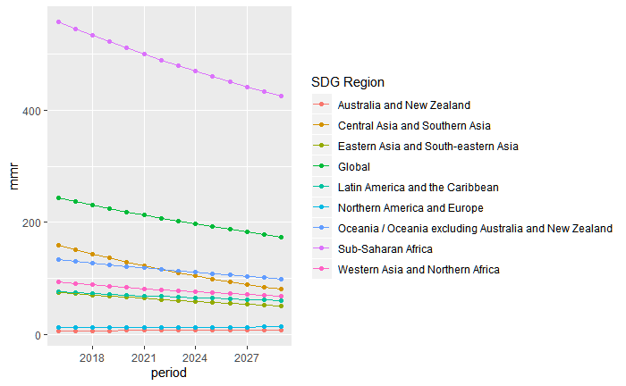

```r
bau_mmr_regional_global_graph(mmr_est_unrounded_pwider, countries_and_regions, live_birth_projections2030, 2016, 2030)
```

#Various tests

```r
#does the calculated sdg arr lead to a global mmr of 70?
 md <- left_join(macp(mmr_est_unrounded_pwider, 2016, 2030) %>% select(-c(`name`)), countries_and_regions, by = c("iso" = "ISOCode")) %>% left_join(live_birth_projections2030 %>% select(`LocID`, `Births`), by = c("ISONum" = "LocID"))
```

```
Column `iso`/`ISOCode` joining factor and character vector, coercing into character vector
```

```r
  #Global MMR using SDG ARR (avg of all countries)
  (sum(get_mmr_sdg_projections(mmr2015, sum(arr_sdg_predictions) / 185, 15) * md$Births)) / (sum(md$Births)) #68.754
```

```
[1] 68.75369
```

```r
  #Global MMR using BAU ARR (avg of all countries)
  bau_mmr_proj <- mmr_est_unrounded_pwider$`2015` * exp(-(rep(0.0273, 185)) * (2030-2015))
   (sum(bau_mmr_proj * md$Births)) / (sum(md$Births)) #166.529
```

```
[1] 166.5286
```

```r
  #(is 170.117 by summary table calculations (using all countries' invidual arrs) above)


  #Global MMR using ARR = 2.9%
  bau_mmr_proj2 <- mmr_est_unrounded_pwider$`2015` * exp(-(rep(0.029, 185)) * (2030-2015))
  (sum(bau_mmr_proj2 * md$Births)) / (sum(md$Births)) #162.336
```

```
[1] 162.3358
```

```r
(sum(get_mmr_sdg_projections(mmr2015, 0.04, 15) * md$Births)) / (sum(md$Births)) #80.325
```

```
[1] 80.32506
```

```r
###

arr_tibble <- cbind(cba(mmr_est_unrounded_pwider), get_arr_sdg_target_country(mmr2015, arr_sdg, 15)) %>%
  rename(`sdg arr` = MMR2015, `bau arr` = arr)

#sdg_mmr_single_country_proj(mmr_est_unrounded_pwider, arr_tibble, "AFG", 2016, 2030)

sdg_mmr_allcountries_proj(mmr_est_unrounded_pwider, arr_tibble, 2016, 2030) %>%
  select(-c("bau arr"))
```

|  | name | iso | sdg arr | 2016 | 2017 | 2018 | 2019 | 2020 | 2021 | 2022 | 2023 | 2024 | 2025 | 2026 | 2027 | 2028 | 2029 | 2030 |
| --- | --- | --- | --- | --- | --- | --- | --- | --- | --- | --- | --- | --- | --- | --- | --- | --- | --- | --- |
| col | Afghanistan | AFG | 0.10740649 | 629.756545 | 565.622456 | 508.019750 | 456.283275 | 409.815616 | 368.080200 | 330.595098 | 296.927460 | 266.688517 | 239.5290927 | 215.135571 | 193.2262724 | 173.548206 | 155.8741443 | 140.0000000 |
| col.1 | Albania | ALB | 0.05603232 | 14.151017 | 13.379908 | 12.650817 | 11.961456 | 11.309660 | 10.693380 | 10.110683 | 9.559737 | 9.038814 | 8.5462757 | 8.080577 | 7.6402548 | 7.223926 | 6.8302844 | 6.4580925 |
| col.2 | Algeria | DZA | 0.05603232 | 107.375992 | 101.524922 | 95.992684 | 90.761906 | 85.816161 | 81.139916 | 76.718486 | 72.537987 | 68.585289 | 64.8479787 | 61.314320 | 57.9732154 | 54.814172 | 51.8272701 | 49.0031284 |
| col.3 | Angola | AGO | 0.05603232 | 237.203912 | 224.278333 | 212.057088 | 200.501795 | 189.576167 | 179.245892 | 169.478528 | 160.243402 | 151.511511 | 143.2554327 | 135.449240 | 128.0684184 | 121.089788 | 114.4914331 | 108.2526319 |
| col.4 | Antigua and Barbuda | ATG | 0.05603232 | 40.948295 | 38.716964 | 36.607222 | 34.612442 | 32.726361 | 30.943055 | 29.256924 | 27.662672 | 26.155294 | 24.7300548 | 23.382479 | 22.1083343 | 20.903620 | 19.7645517 | 18.6875532 |
| col.5 | Argentina | ARG | 0.05603232 | 39.146595 | 37.013442 | 34.996527 | 33.089516 | 31.286421 | 29.581580 | 27.969637 | 26.445532 | 25.004477 | 23.6419477 | 22.353664 | 21.1355813 | 19.983873 | 18.8949237 | 17.8653124 |
| col.6 | Armenia | ARM | 0.05603232 | 26.081907 | 24.660667 | 23.316872 | 22.046303 | 20.844968 | 19.709096 | 18.635119 | 17.619665 | 16.659545 | 15.7517423 | 14.893407 | 14.0818445 | 13.314505 | 12.5889784 | 11.9029871 |
| col.7 | Australia | AUS | 0.05603232 | 6.069945 | 5.739185 | 5.426449 | 5.130754 | 4.851172 | 4.586825 | 4.336882 | 4.100559 | 3.877114 | 3.6658445 | 3.466087 | 3.2772154 | 3.098635 | 2.9297862 | 2.7701380 |
| col.8 | Austria | AUT | 0.05603232 | 4.826279 | 4.563288 | 4.314628 | 4.079518 | 3.857219 | 3.647034 | 3.448301 | 3.260399 | 3.082735 | 2.9147523 | 2.755923 | 2.6057491 | 2.463758 | 2.3295044 | 2.2025664 |
| col.9 | Azerbaijan | AZE | 0.05603232 | 25.435352 | 24.049344 | 22.738861 | 21.499788 | 20.328234 | 19.220519 | 18.173166 | 17.182884 | 16.246564 | 15.3612661 | 14.524209 | 13.7327640 | 12.984446 | 12.2769052 | 11.6079192 |

[output cut: 175 more lines]

```r
mmr_allcountries_projections(mmr_est_unrounded_pwider, 2010, 2017, 2016, 2030)
```

|  | iso | name | arr | 2016 | 2017 | 2018 | 2019 | 2020 | 2021 | 2022 | 2023 | 2024 | 2025 | 2026 | 2027 | 2028 | 2029 | 2030 |
| --- | --- | --- | --- | --- | --- | --- | --- | --- | --- | --- | --- | --- | --- | --- | --- | --- | --- | --- |
| col | AFG | Afghanistan | 0.0575321980 | 661.961636 | 624.952349 | 590.012195 | 557.025494 | 525.883029 | 496.481694 | 468.724143 | 442.518476 | 417.7779280 | 394.4205874 | 372.369121 | 351.5505189 | 331.8958539 | 313.3400519 | 295.8216771 |
| col.1 | ALB | Albania | 0.0454473686 | 14.301600 | 13.666179 | 13.058989 | 12.478777 | 11.924343 | 11.394543 | 10.888283 | 10.404515 | 9.9422413 | 9.5005065 | 9.078398 | 8.6750438 | 8.2896107 | 7.9213024 | 7.5693581 |
| col.2 | DZA | Algeria | 0.0038325706 | 113.129861 | 112.697113 | 112.266020 | 111.836576 | 111.408774 | 110.982609 | 110.558075 | 110.135164 | 109.7138712 | 109.2941898 | 108.876114 | 108.4596369 | 108.0447533 | 107.6314566 | 107.2197409 |
| col.3 | AGO | Angola | 0.0429198704 | 240.334718 | 230.237812 | 220.565095 | 211.298748 | 202.421696 | 193.917587 | 185.770750 | 177.966177 | 170.4894889 | 163.3269101 | 156.465244 | 149.8918501 | 143.5946162 | 137.5619408 | 131.7827092 |
| col.4 | ATG | Antigua and Barbuda | 0.0062832992 | 43.036956 | 42.767390 | 42.499512 | 42.233312 | 41.968780 | 41.705904 | 41.444675 | 41.185082 | 40.9271151 | 40.6707640 | 40.416019 | 40.1628688 | 39.9113046 | 39.6613161 | 39.4128935 |
| col.5 | ARG | Argentina | 0.0373587459 | 39.884470 | 38.421926 | 37.013012 | 35.655763 | 34.348284 | 33.088749 | 31.875400 | 30.706545 | 29.5805504 | 28.4958459 | 27.450917 | 26.4443051 | 25.4746052 | 24.5404637 | 23.6405768 |
| col.6 | ARM | Armenia | 0.0312303710 | 26.736878 | 25.914779 | 25.117959 | 24.345638 | 23.597065 | 22.871508 | 22.168261 | 21.486637 | 20.8259716 | 20.1856201 | 19.564958 | 18.9633796 | 18.3802986 | 17.8151459 | 17.2673704 |
| col.7 | AUS | Australia | -0.0236929742 | 6.573687 | 6.731297 | 6.892686 | 7.057944 | 7.227165 | 7.400442 | 7.577875 | 7.759561 | 7.9456031 | 8.1361060 | 8.331176 | 8.5309236 | 8.7354600 | 8.9449004 | 9.1593623 |
| col.8 | AUT | Austria | 0.0136878097 | 5.035034 | 4.966585 | 4.899066 | 4.832465 | 4.766770 | 4.701968 | 4.638047 | 4.574995 | 4.5127997 | 4.4514502 | 4.390935 | 4.3312419 | 4.2723606 | 4.2142797 | 4.1569885 |
| col.9 | AZE | Azerbaijan | 0.0278329547 | 26.162822 | 25.444674 | 24.746238 | 24.066974 | 23.406355 | 22.763870 | 22.139020 | 21.531322 | 20.9403047 | 20.3655104 | 19.806494 | 19.2628216 | 18.7340728 | 18.2198377 | 17.7197180 |

[output cut: 175 more lines]

```r
NA
```